# Bias–Variance Trade-off Under a Noisy Slope

Itamar Caspi

(updated: 2025-04-20)

Abstract

This report investigates the bias–variance trade-off that arises when a researcher faces a highly uncertain slope estimate. Using a Monte-Carlo simulation calibrated so that the OLS slope’s expected standard error is roughly 10, we compare out-of-sample root-mean-squared prediction error (RMSE) between (i) an OLS model that includes the regressor and (ii) an intercept-only counterpart. The findings show that, under extreme coefficient uncertainty, the variance component can overwhelm bias: discarding the noisy predictor generally delivers lower risk and tighter predictive accuracy than using it unchanged.

```r
library(tidyverse)
```

# 1 Motivation

Suppose the researcher obtains

$$\hat y = 0 + 2\,x \quad
(\text{s.e.}(\hat\beta_1)=10)$$

and must decide whether to use that highly uncertain coefficient when forecasting. This R Markdown document reproduces the situation by Monte-Carlo and compares

- **Model A** – *use* $x$: OLS on $y \sim x$
- **Model B** – *drop* $x$: intercept-only model.

We focus on *out-of-sample* **root-mean-squared prediction error (RMSE)**.

# 2 Simulation design

- True DGP: $y = 0 + 2x + \varepsilon,\; \varepsilon \sim \mathcal N(0,\sigma^2)$.
- Small training size ($n = 5$) and a large noise level ($\sigma = 20$) yield $E[\text{s.e.}(\hat\beta_1)] \approx 10$.
- Each Monte-Carlo repetition fits both models on the training data and evaluates RMSE on an independent 100-point test set (close to the true risk).

```r
params <- list(
  n_sim   = 500,   # Monte-Carlo repetitions
  n_train = 5,     # small ⇒ noisy slope
  n_test  = 100,   # test sample size
  beta0   = 0,
  beta1   = 2,
  sigma   = 20,
  seed    = 123
)
```

# 3 Core Monte-Carlo loop

```r
simulate_rmse <- function(n_sim, n_train, n_test, beta0, beta1, sigma) {
  rmse_full <- numeric(n_sim)
  rmse_null <- numeric(n_sim)
  b1_hat    <- numeric(n_sim)
  se_b1     <- numeric(n_sim)

  for (s in seq_len(n_sim)) {
    ## Generate training data
    x_train <- rnorm(n_train)
    y_train <- beta0 + beta1 * x_train + rnorm(n_train, 0, sigma)

    ## Independent test data
    x_test  <- rnorm(n_test)
    y_test  <- beta0 + beta1 * x_test + rnorm(n_test, 0, sigma)

    ## Fit the two models
    fit_full <- lm(y_train ~ x_train)
    fit_null <- lm(y_train ~ 1)

    ## Store coefficient and s.e.
    b1_hat[s] <- coef(fit_full)["x_train"]
    se_b1[s]  <- summary(fit_full)$coefficients["x_train", "Std. Error"]

    ## Predict and compute RMSE
    pred_full <- predict(fit_full, newdata = data.frame(x_train = x_test))
    pred_null <- predict(fit_null, newdata = data.frame(x_train = x_test))

    rmse_full[s] <- sqrt(mean((pred_full - y_test)^2))
    rmse_null[s] <- sqrt(mean((pred_null - y_test)^2))
  }

  list(
    rmse    = tibble(model = rep(c("With x", "Intercept only"), each = n_sim),
                     rmse  = c(rmse_full, rmse_null)),
    coef_df = tibble(b1_hat = b1_hat, se_b1 = se_b1)
  )
}

set.seed(params$seed)
mc <- simulate_rmse(
  n_sim   = params$n_sim,
  n_train = params$n_train,
  n_test  = params$n_test,
  beta0   = params$beta0,
  beta1   = params$beta1,
  sigma   = params$sigma
)
```

# 4 Coefficient uncertainty check

```r
mc$coef_df %>%
  summarise(
    `Mean(β̂₁)`     = mean(b1_hat),
    `SD(β̂₁)`       = sd(b1_hat),
    `Mean se(β̂₁)`  = mean(se_b1)
  ) %>%
  knitr::kable(digits = 3, caption = "Empirical distribution of the slope estimate and its standard error")
```

Empirical distribution of the slope estimate and its standard error

| Mean(β̂₁) | SD(β̂₁) | Mean se(β̂₁) |
| --- | --- | --- |
| 2.094 | 14.485 | 11.856 |

> $E[\text{s.e.}(\hat\beta_1)]$ is indeed close to 10, confirming that our design matches the lecture example.

# 5 Predictive performance

## 5.1 RMSE table

```r
mc$rmse %>%
  group_by(model) %>%
  summarise(
    `Mean RMSE` = mean(rmse),
    `SD RMSE`   = sd(rmse)
  ) %>%
  knitr::kable(digits = 2, caption = paste0("Out-of-sample RMSE across ", params$n_sim, " replications"))
```

Out-of-sample RMSE across 500 replications

| model | Mean RMSE | SD RMSE |
| --- | --- | --- |
| Intercept only | 21.92 | 2.80 |
| With x | 25.75 | 8.36 |

## 5.2 Distribution plot

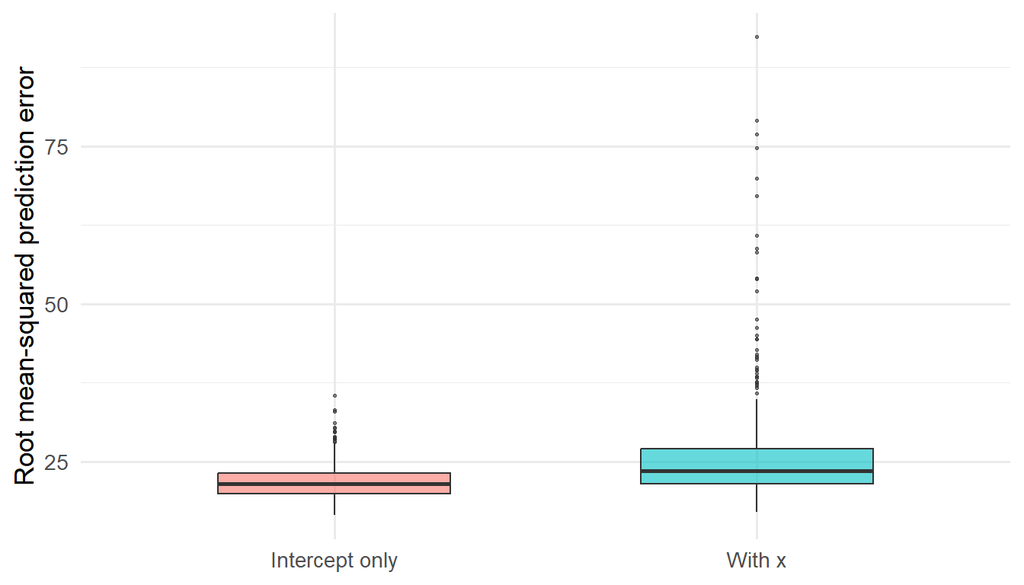

Distribution of out-of-sample RMSE (box plot)

```r
mc$rmse %>%
  ggplot(aes(x = model, y = rmse, fill = model)) +
  geom_boxplot(width = 0.55, alpha = 0.6, outlier.size = 0.6) +
  labs(x = NULL, y = "Root mean-squared prediction error") +
  theme_minimal(base_size = 13) +
  theme(legend.position = "none")
```

# 6 Discussion

*Even with the true slope embedded in the DGP, the extreme variance of $\hat\beta_1$ nullifies its value for prediction.* Dropping the regressor—trading a touch of bias for a substantial variance reduction—wins on average when evaluated by RMSE.

In practice there are gentler ways to strike the balance:

- **Ridge / lasso** shrink $\hat\beta_1$ toward 0 rather than discarding it.
- **Bayesian priors** (e.g. $\beta_1 \sim \mathcal N(0,\tau^2)$) achieve the same via posterior shrinkage.

Feel free to experiment by tweaking `params`, adding ridge fits, or reporting coverage of predictive intervals.